# DATA3888 2024: Assignment Sample Solutions

DATA3888 tutors

This report contains sample solutions for the DATA3888 2024 assignment. These solutions only provides a guide of what could be done; questions are likely to have more than one correct solution. We start by loading in all the packages that will be used.

```r
library(tidyverse)    # Data manipulation and plotting
library(tuneR)        # Read in wave files
library(stringdist)   # Levenshtein similarity
library(Biobase)      # Read in and work with GSE files
library(limma)        # Gene expression analysis
library(DT)           # Interactive tables
library(cvTools)      # Cross-validation
library(randomForest) # Random forests
library(viridis)      # Viridis colour scheme
library(tsfeatures)   # Time series features
```

# Question 1: Reef

Between 2014-2017, marine scientists recorded an unprecedented global coral bleaching event. Your friend Farhan is a marine science expert who wants to study the environmental variables that may have triggered this event. To do this, we will use a public dataset, curated by Sally and colleagues. This dataset records coral bleaching events at 3351 locations in 81 countries from 1998 to 2017 with a suite of environmental and temperature metrics. The data is in the file `Reef_Check_with_cortad_variables_with_annual_rate_of_SST_change.csv` and the full description of the variables can be found in the supplementary table of the [study](https://www.nature.com/articles/s41467-019-09238-2#Sec7).

## Part (a)

Farhan has noticed on average the North of Australia experienced higher levels of coral bleaching compared to the South, during the global bleaching event from 2014-2017. In the authors find that the following variables are associated with the probability of coral bleaching.

- `TSA_Frequency_Standard_Deviation`
- `Temperature_Mean`
- `TSA_Frequency`
- `Temperature_Kelvin_Standard_Deviation`
- `TSA_DHW_Standard_Deviation`
- `SSTA_Frequency_Standard_Deviation`

Create **one informative graphic** to visualise how these six variables are different between the North and South of Australia during the 2014-2017 global coral bleaching event. Explain any data filtering or transformation that you perform. Comment on the visualisation and suggest at least one variable that appears to be different between the North and the South and thus may be associated with the higher levels of bleaching observed in the North.

*Note:* The midpoint of Australia is located at -23 degrees Latitude. Observations higher than -23 degrees latitude is considered North Australia. Your graphic can have multiple panels.

#### Sample solution

We filter observations which are between 2014-2017 and in Australia. Points higher than -23 degrees latitude are labelled as North and points below are labelled as South. Only the relevant variables are retained. To plot the data using ggplot the measurements are transformed from a wide format to a long format.

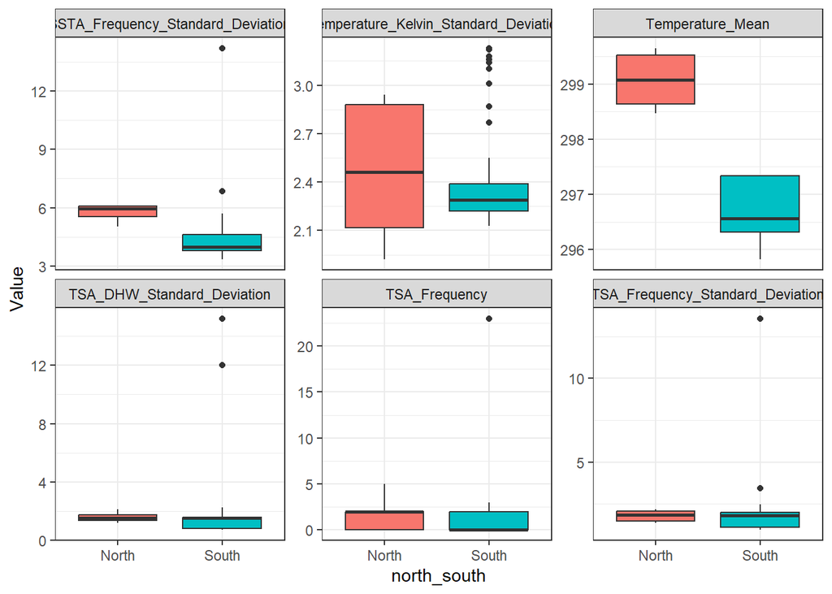

```r
reef <- read.csv("data/Reef_Check_with_cortad_variables_with_annual_rate_of_SST_change.csv")
reef_keep <- reef %>%
  filter(Year %in% 2014:2017) %>%
  filter(Country == "Australia")  %>%
  mutate(north_south = ifelse(Latitude.Degrees > -23, "North", "South")) %>%
  select(TSA_Frequency_Standard_Deviation,
         Temperature_Mean,
         TSA_Frequency,
         Temperature_Kelvin_Standard_Deviation,
         TSA_DHW_Standard_Deviation,
         SSTA_Frequency_Standard_Deviation,
         north_south)

reef_keep %>%
  pivot_longer(cols = -c(north_south), names_to = "Measurement", values_to = "Value") %>%
  ggplot(aes(x = north_south, y = Value, fill = north_south)) +
  geom_boxplot() +
  facet_wrap(~Measurement, scales = "free_y") +
  theme_bw() +
  guides(fill = "none")
```

- Variables relating with TSA appear to be very similar in the North and South.
- The variation of `Temperature_Kelvin_Standard_Deviation` is very different between the North and South.
- Some variables like `SSTA_Frequency_Standard_Deviation` and `Temperature_Mean` appear to be quite different between North and South Australia.

## Part (b)

Farhan is interested in exploring which reefs were the most affected by the 2014-2017 global bleaching event, across the globe. Create an **interactive map visualisation** to show the average proportion of coral bleaching between 2014-2017, that allows a marine scientist to identify the names of the most affected coral reefs, the region (recorded as `State.Province.Island`) and the values of the measurements of the associated environmental variables identified in part (a). Justify your choice of visualisation, and comment on the result. Suggest 4 regions that were the most affected by the bleaching event.

#### Sample solution

- We use colour and size to emphasise the most affected reefs

```r
reef_2014_2017 <- reef %>% filter(Year %in% 2014:2017)

library(leaflet)
popupContent <- function(data) {
  paste(
    "<strong>Reef Name:</strong>", reef_2014_2017$Reef.Name, "<br/>",
    "<strong>Region:</strong>", reef_2014_2017$State.Province.Island, "<br/>",
    "<strong>Average Bleaching:</strong>", reef_2014_2017$Average_bleaching, "<br/>",
    "<strong>Thermal Stress Anomaly Frequency:</strong>", reef_2014_2017$TSA_Frequency, "<br/>",
    "<strong>Mean Temperature:</strong>", reef_2014_2017$Temperature_Mean, "<br/>"
  )
}

pal <- colorNumeric(palette = "YlOrRd", domain = reef_2014_2017$Average_bleaching)
leaflet(data = reef_2014_2017) %>% addTiles() %>%
    addCircleMarkers(lat = ~Latitude.Degrees,
                     lng = ~Longitude.Degrees,
                     popup = ~popupContent(.),
                     color = ~pal(Average_bleaching),
                     stroke = FALSE,
                     fillOpacity = 0.6,
                     radius = ~(Average_bleaching)/10+5) %>%
    addLegend(position = "bottomleft", pal = pal, values = ~Average_bleaching)
```

[interactive chart not shown]

## Part (c)

Farhan wants to explore the impact of environmental variables on coral bleaching in the most affected regions. For the regions identified in part (b), create **one informative visualisation** to show how the average bleaching has changed over time (not restricted to 2014-2017), and its relationship with one of the associated environmental variables identified in part (a). Comment on the visualisation.

*Note: your graphic can have multiple panels.*

#### Sample solution

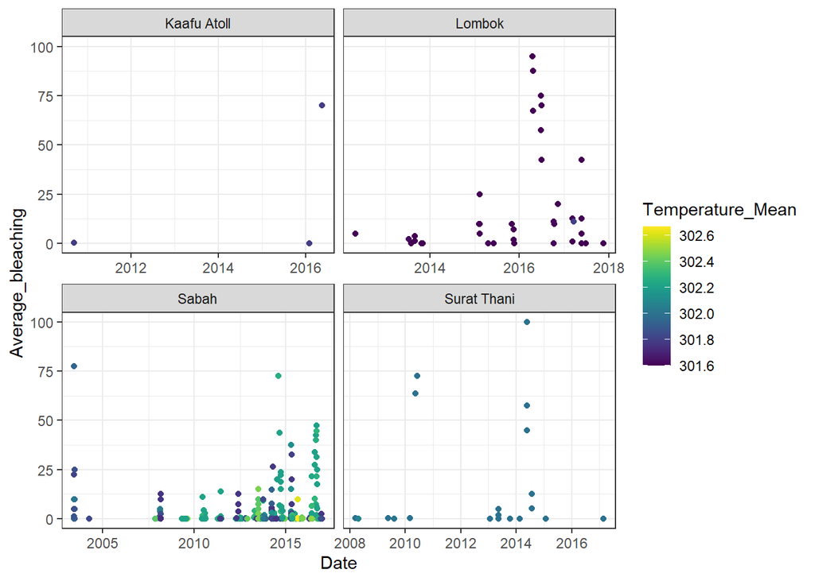

```r
affected_regions <- c("Lombok", "Surat Thani", "Kaafu Atoll", "Sabah")
reef %>%
  filter(State.Province.Island %in% affected_regions) %>%
  mutate(Date = dmy(Date)) %>%
  ggplot(aes(x = Date, y = Average_bleaching, colour = Temperature_Mean)) +
  geom_point() +
  scale_colour_viridis() +
  facet_wrap(~State.Province.Island, scales = "free_x") +
  theme_bw()
```

- We can see that these reefs experienced higher bleaching between 2014-2017
- The Sabah region has increased temperature over time, as well as increased bleaching.

# Question 2: Kidney

Your friend Harry is a nephrologist (kidney specialist) who is interested in building an accurate classifier to detect graft rejection in his kidney transplant patients. He is also interested in knowing which genes may be affecting graft rejection. In this problem, we will build a classification model using the public data set GSE138043. We will perform feature selection and build a classifier, estimating its accuracy on unseen data.

## Part (a)

Harry wants to know which genes are the most differentially expressed genes between patients that experience graft rejection and stable patients. Use the `topTable` function in the `limma` package to output the **gene symbols** of the 10 most differentially expressed genes.

*Hint*. In the GSE138043 dataset, the outcome is found in the `characteristics_ch1` column of the `phenoData` and the gene symbols are found the in `gene_assignment` column of the `featureData`, between the first and second `//` symbols.

#### Sample solution

```r
load("data/GSE138043.RData")
gse$Outcome <- ifelse(grepl("non-AR", pData(gse)$characteristics_ch1), "Stable", "Rejection")
fData(gse)$gene_assignment <- sapply(fData(gse)$gene_assignment, function(x) strsplit(x, " // ")[[1]][2]) %>% unname()

featureData1_raw <- fData(gse)
design1_raw <- model.matrix(~Outcome, data = pData(gse))
fit1_raw <- lmFit(exprs(gse), design1_raw)
fit1_raw <- eBayes(fit1_raw)

topTable(fit1_raw, genelist = featureData1_raw[, "gene_assignment"], n = 10) %>%
  mutate_if(is.numeric, .funs = function(x) signif(x,3)) %>%
  DT::datatable()
```

```
## Removing intercept from test coefficients
```

|  | ID | logFC | AveExpr | t | P.Value | adj.P.Val | B |
| --- | --- | --- | --- | --- | --- | --- | --- |
| 3066751 | SYPL1 | 0.49 | 8.62 | 6.9 | 6.14e-09 | 0.000104 | 10.1 |
| 2755154 | F11 | 1.12 | 7.35 | 6.13 | 1.09e-07 | 0.000922 | 7.46 |
| 2590736 | NCKAP1 | 0.645 | 8.69 | 5.94 | 2.16e-07 | 0.00122 | 6.84 |
| 2337716 | PRKAA2 | 0.794 | 8.99 | 5.84 | 3.16e-07 | 0.00133 | 6.5 |
| 2395146 | TNFRSF9 | -0.483 | 4.34 | -5.66 | 6.07e-07 | 0.00163 | 5.9 |
| 2485176 | MDH1 | 0.709 | 9.01 | 5.64 | 6.6e-07 | 0.00163 | 5.82 |
| 2380785 | LYPLAL1 | 0.921 | 7.33 | 5.63 | 6.76e-07 | 0.00163 | 5.8 |
| 2620018 | C3orf23 | 0.732 | 6.54 | 5.59 | 7.75e-07 | 0.00164 | 5.67 |
| 3959986 | IL2RB | -0.586 | 4.57 | -5.54 | 9.35e-07 | 0.00175 | 5.5 |
| 3070610 | IQUB | 0.7 | 5.07 | 5.51 | 1.06e-06 | 0.00177 | 5.39 |

## Part (b)

Harry wants to build a random forest classifier to predict whether a patient is stable or experiencing graft rejection and estimate its accuracy on unseen data. To do this, Harry tries to perform repeated cross-validation on the entire data set, but it takes too long to run. To speed up the model training, Harry knows he can implement feature selection in one of 3 parts of the framework (`OPTION A`, `OPTION B`, or `OPTION C`), however he is not sure which one.

Explain the difference (if any) between the 3 options and which option(s) would be the most appropriate for Harry’s task.

```
set.seed(3888)

X = t(exprs(gse))
y = ifelse(grepl("non-AR", pData(gse)$characteristics_ch1), "Stable", "Rejection")

cvK = 5
n_sim = 50

cv_accuracy_gse1b = numeric(n_sim)

### OPTION A ###

for (i in 1:n_sim) {
  cvSets = cvFolds(nrow(X), cvK)
  cv_accuracy_folds = numeric(cvK)

  ### OPTION B ###

  for (j in 1:cvK) {
    test_id = cvSets$subsets[cvSets$which == j]
    X_train = X[-test_id,]
    X_test = X[test_id,]
    y_train = y[-test_id]
    y_test = y[test_id]

    ### OPTION C ###

    rf_fit = randomForest(x = X_train, y = as.factor(y_train))
    predictions = predict(rf_fit, X_test)
    cv_accuracy_folds[j] = mean(y_test == predictions)
  }
  cv_accuracy_gse1b[i] = mean(cv_accuracy_folds)
}
```

#### Sample solution

- options A and B would produce the same result because they perform feature selection on the entire data set. However, option B would be more computationally expensive as it is performed again for each repeat.
- option C gives a different result as it only performs feature selection on the training data in the innermost CV loops.
- Option C is the most valid, as it represents the performance of the framework on unseen data, so that the test data is independent of the feature selection.

## Part (c)

Harry wants to implement feature selection in the most appropriate option of Part (b), but he’s not sure how many features he should select. Use the framework from part (b) to evaluate the performance of a random forest classifier on unseen data with feature selection taking the top 10, 50 or 100 genes. Visualise your results and comment on them. How many features would you recommend Harry to use?

*Hint: if implemented correctly, this code should take no more than a few minutes to run.*

#### Sample solution

```r
set.seed(3888)

X = t(exprs(gse))
y = factor(ifelse(grepl("non-AR", pData(gse)$characteristics_ch1), "Stable", "Rejection"))

cvK = 5
n_sim = 20

cv_accuracy10 = cv_accuracy50 = cv_accuracy100 = numeric(n_sim)

for (i in 1:n_sim) {
  cvSets = cvFolds(nrow(X), cvK)
  cv_accuracy_folds10 = cv_accuracy_folds50 = cv_accuracy_folds100 = numeric(cvK)

  for (j in 1:cvK) {
    test_id = cvSets$subsets[cvSets$which == j]
    X_train = X[-test_id,]
    X_test = X[test_id,]
    y_train = y[-test_id]
    y_test = y[test_id]

    design <- model.matrix(~y_train)
    fit <- lmFit(t(X_train), design)
    fit <- eBayes(fit)
    top <- topTable(fit, n = 100)
    DE_genes10 <- rownames(top)[1:10]
    DE_genes50 <- rownames(top)[1:50]
    DE_genes100 <- rownames(top)[1:100]

    X_train10 = X_train[,DE_genes10]
    X_test10 = X_test[,DE_genes10]
    rf_fit10 = randomForest(x = X_train10, y = y_train)
    predictions10 = predict(rf_fit10, X_test10)
    cv_accuracy_folds10[j] = mean(y_test == predictions10)

    X_train50 = X_train[,DE_genes50]
    X_test50 = X_test[,DE_genes50]
    rf_fit50 = randomForest(x = X_train50, y = y_train)
    predictions50 = predict(rf_fit50, X_test50)
    cv_accuracy_folds50[j] = mean(y_test == predictions50)

    X_train100 = X_train[,DE_genes100]
    X_test100 = X_test[,DE_genes100]
    rf_fit100 = randomForest(x = X_train100, y = y_train)
    predictions100 = predict(rf_fit100, X_test100)
    cv_accuracy_folds100[j] = mean(y_test == predictions100)

  }
  cv_accuracy10[i] = mean(cv_accuracy_folds10)
  cv_accuracy50[i] = mean(cv_accuracy_folds50)
  cv_accuracy100[i] = mean(cv_accuracy_folds100)

  if(i %% 5 == 0){print(i)}
}
```

```
## [1] 5
## [1] 10
## [1] 15
## [1] 20
```

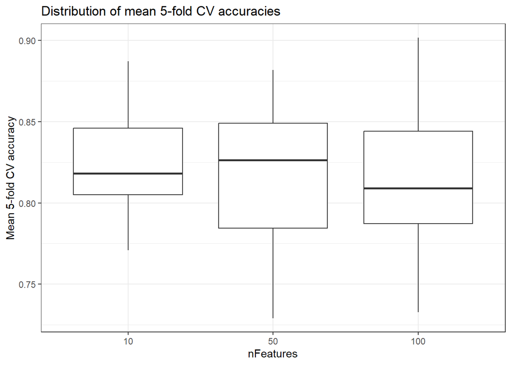

```r
plot_df = data.frame(accuracy = c(cv_accuracy10,
                                  cv_accuracy50,
                                  cv_accuracy100),
                     nFeatures = factor(rep(c(10, 50, 100), each = n_sim)))

ggplot(data = plot_df, aes(x = nFeatures, y = accuracy)) +
  geom_boxplot() +
  labs(x = "nFeatures", y = "Mean 5-fold CV accuracy", title = "Distribution of mean 5-fold CV accuracies") +
  theme(plot.title = element_text(hjust = 0.5, size = 12)) +
  theme_bw()
```

- 10 features and 50 features give similar performance, where 50 features has a slightly higher median. 100 features gives slightly lower performance.
- We suggest Harry to use 50 features as it has the highest median. Note that one could also argue to use 10 features, as using it has a comparable accuracy, but would be a simpler and more interpretable model.

## Part (d)

Using the optimal number number of features found in part (c), build a random forest classifier on the entire training data set, that Harry could implement on future data. Harry wants to know which genes are the most important in making the classification. Output the gene symbols of the top 10 genes in terms of importance in the random forest classifier. Comment on the overlap between the top 10 important genes in the classifier and the top 10 differentially expressed genes (if your final model only uses 10 genes, comment on the concordance in ranking of the 10 genes).

*Hint*. In a random forest model `fit`, the feature importance can be obtained by `fit$importance`, where a higher value indicates higher importance in the classifier.

#### Sample solution

```r
set.seed(3888)
design <- model.matrix(~y)
fit <- lmFit(t(X), design)
fit <- eBayes(fit)
top <- topTable(fit, n = 50, genelist = featureData1_raw[, "gene_assignment"])
```

```
## Removing intercept from test coefficients
```

```r
DE_genes50 <- rownames(top)
DE_genes_names <- top$ID

X_50 = X[,DE_genes50]
colnames(X_50) <- DE_genes_names
rf_fit_final = randomForest(x = X_50, y = y)

gene_importance <- rf_fit_final$importance %>% data.frame() %>% arrange(-MeanDecreaseGini) %>% head(10)
gene_importance
```

```
##          MeanDecreaseGini
## SYPL1           2.7607381
## C3orf23         1.4834876
## IQUB            0.9991497
## PRKAA2          0.8113707
## STEAP2          0.8079412
## C1QTNF7         0.6789616
## AKNA            0.6365719
## BRP44L          0.6101020
## PVRL3           0.5928094
## TMEM106B        0.5113312
```

```r
intersect(DE_genes_names[1:10], rownames(gene_importance))
```

```
## [1] "SYPL1"   "PRKAA2"  "C3orf23" "IQUB"
```

- There are 4 genes that are overlapped between the 10 most important and the 10 most differentially expressed.
- It is expected that there should be some overlap because differentially expressed genes are likely to use useful in distinguishing the two classes.
- Having some important genes which are not that differentially expressed suggests that they may be helpful in classifying the two classes in a more complex relationship (which is captured by the random forest).

# Question 3: Brain

Your friend Martin is a physicist who needs your help in building a classifier to detect left and right eye movements from brain EEG signals in real time. He has a data set stored under `zoe_spiker.zip` that contains brain signal series (each series is a file) which corresponds to sequences of eye movements of varying lengths.

The file name corresponds to the true eye movement. For example the file `LRL_z.wav` corresponds to left-right-left eye movements; the file `LLRLRLRL_z.wav` corresponds to left-left-right-left-right-left-right-left eye movements. There are a total of 31 files.

The folder also contains two RDS files which may be used to train an event detection classifier (`training_data.rds`, `training_labels.rds`)

## Part (a)

The first stage of our classifier is to identify events (eye movement). Martin has provided some training data (`training_data.rds`) which corresponds to waves, and labels (`training_labels.rds`) where `TRUE` represents the presence of an event and `FALSE` represents no event. Use the `tsfeatures` package to calculate some autocorrelation features and build a random forest classifier to detect events.

Report and comment on the accuracy of this model.

*Hint*. Use `tsfeatures(training_data, c("acf_features"))` to compute the autocorrelation features from `training_data`. In a random forest model `fit`, the confusion matrix of out-of-bag predictions can be obtained by `fit$confusion`. In a random forest classifier, the out-of-bag predictions can be treated as the predictions on a independent data set.

#### Sample solution

```r
set.seed(3888)
training_data = readRDS("data/zoe_spiker/training_data.rds")
training_labels = readRDS("data/zoe_spiker/training_labels.rds")

training_features <- tsfeatures(training_data, c("acf_features"))

event_RF =  randomForest::randomForest(x = training_features, y = as.factor(training_labels))

event_RF
```

```
##
## Call:
##  randomForest(x = training_features, y = as.factor(training_labels))
##                Type of random forest: classification
##                      Number of trees: 500
## No. of variables tried at each split: 2
##
##         OOB estimate of  error rate: 0%
## Confusion matrix:
##       FALSE TRUE class.error
## FALSE    72    0           0
## TRUE      0   72           0
```

- The Random Forest classifier has a 100% accuracy.
- This means that our model can easily detect events from non-events.

## Part (b)

Build a classification rule for detecting {L,R} under a **streaming condition**, using the trained Random Forest model from part (a) in a window to identify events, and using the min-max rule to classify events into “Left” or “Right” (Lab 3 Exercise 2.3). Demonstrate your classifier on a length 3, 8 and long wave file (note that the result should be reasonable, but doesn’t have to be good). You may use the following code template.

```
ts_features_classifier = function(wave_file,
                                  window_multiplier = 1) {

  window_size = [email protected]*window_multiplier
  increment = window_size/3

  Y = wave_file@left
  xtime = seq_len(length(Y))/[email protected]
  predicted_labels = c()
  window_lb = 1
  max_time = length(Y)

  while(max_time > window_lb + window_size) {

    window_ub = window_lb + window_size
    window = Y[window_lb:window_ub]

    event = <event detection>

    if (event) {
      predicted = <LR prediction>
      predicted_labels = c(predicted_labels, predicted)
      window_lb = window_lb + window_size
    } else {
      window_lb = window_lb + increment
    }
  }
  return(paste(predicted_labels, collapse = ""))
}
```

#### Sample solution

We start by loading in the data.

```r
## Short wave files
dir_short = "data/zoe_spiker/Length3/"
all_files_short <- list.files(dir_short)

wave_file_short <- list()
for (i in all_files_short) {
wave_file_short[[i]] <- readWave(file.path(dir_short, i))
}

## Medium wave files

dir_medium = "data/zoe_spiker/Length8/"
all_files_medium <- list.files(dir_medium)

wave_file_medium <- list()
for (i in all_files_medium) {
wave_file_medium[[i]] <- readWave(file.path(dir_medium, i))
}

## Long wave files

dir_long = "data/zoe_spiker/Long/"
all_files_long <- list.files(dir_long)

wave_file_long <- list()
for (i in all_files_long) {
wave_file_long[[i]] <- readWave(file.path(dir_long, i))
}
```

Before we build a streaming classifier, we first need to gather the components of a basic eye movement classifier that is able to distinguish between no eye movement, left eye movements and right eye movements.

Copy-pasting the left-right classification algorithm (Lab 3 Exercise 2.3):

```r
LR_detection = function(seq) {
  maxval = which.max(seq)
  minval = which.min(seq)
  movement = ifelse(maxval < minval,  "L", "R")
  return(movement)
}
```

```r
ts_features_classifier = function(wave_file,
                                  window_multiplier = 1) {

  window_size = wave_file@samp.rate*window_multiplier
  increment = window_size/3

  Y = wave_file@left
  xtime = seq_len(length(Y))/wave_file@samp.rate
  predicted_labels = c()
  window_lb = 1 # Lower bound of the window should start from index 1 (start of signal)
  max_time = length(Y)

  while(max_time > window_lb + window_size) {

    window_ub = window_lb + window_size
    window = Y[window_lb:window_ub]

    # Calculate ts features for the window file
    ts_features =  tsfeatures(window, c("acf_features")) #tsfeatures(window, c("lumpiness", "acf_features", "frequency"))

    # Using pre-trained model on ts features
    event = predict(event_RF, ts_features)

    if (event) {
      # Event detected, need to determine whether left or right
      predicted = LR_detection(window)
      predicted_labels = c(predicted_labels, predicted)
      window_lb = window_lb + window_size # Just found event; use larger increment
    } else {
      # No event detected; immediately move to next window
      window_lb = window_lb + increment # Still looking for event; use smaller increment
    }
  }
  return(paste(predicted_labels, collapse = "")) # Convert vector of predictions to string
}
```

A brief explanation of the key variables above are provided:

- `wave_file`: The complete wave file (S4 object) as read in using the `tuneR::readWave` function.
- `window_size`: The size of the rolling window in ticks/indices (not seconds). Set to 10000 (1 second).
- `window_mulitiplier`: An integer to multiply the `window_size` by. Corresponds to the number of seconds the window should cover.
- `increment`: The amount the rolling window gets incremented ahead in ticks/indices after each while loop iteration. Set to one third of the window size.
- `Y`: The signal (strength) measurements from the wave file, stored as a vector.
- `xtime`: The time stamps (in seconds) associated with each signal measurement, stored as a vector.
- `predicted_labels`: A vector to store the predictions of left/right eye movements.
- `window_lb`: The lower bound of the rolling window in the current while loop iteration, in indices/ticks.
- `window_ub`: The upper bound of the rolling window in the current while loop iteration, in indices/ticks.
- `max_time`: The length of the wave file (in ticks); used to calculate when to stop the while loop.
- `window`: The rolling window in the current while loop iteration (used in prediction).

As for the logic of the actual while loop, while the code should mostly be self-explanatory, a summary is given below:

- Until the window reaches the end of the file, continue the while loop. In particular, keep continuing until the lower bound of the window is within one window size away from the end of the file; if we try to start a new iteration in this case, then the end of the window will extend beyond the end of the file, which does not make sense.
- Calculate the time series features for the current window. Use these features with the Random Forest model to determine if there is an event. We call on `LR_detection` to classify this event as left or right, before storing the result in `predicted_labels` and moving the window forward. On the other hand, if this number is above the threshold, then we say that there is no event, and immediately move the window forward.
- If an event is detected, then the window is incremented forward by a larger amount (`window_size`) compared to the forward increment when an event is not detected. This is because we assume that after an event, there is not going to be another event for some time, and so moving forward the window a larger amount is more efficient. In addition, this approach helps us reduce multiple event detections for what is actually a single event in the data.

Some example predictions from each of the short, medium and long sets:

```r
ts_features_classifier(wave_file_short[[2]])  # Actual label is LLL
```

```
## [1] "LLRLLRLR"
```

```r
ts_features_classifier(wave_file_medium[[4]]) # Actual label is LRRRLLRL
```

```
## [1] "LRLRRLRRLLRRLRRLLRLLLLR"
```

```r
ts_features_classifier(wave_file_long[[1]])   # Actual label is LLLRLLLRLRRLRRRLRLLL
```

```
## [1] "LRLRRLRRLLRLLLRRRLLRRRRLRLRLRRRLRLRRLLRRLRRRRLRLLLRRLRLRL"
```

- Our current implementation of the streaming classifier does not perform very well and outputs too many labels.

## Part (c)

Martin thinks multiple window sizes must be evaluated to find the best Random Forest streaming classifier.

Compare the performance of the Random Forest streaming classifier for detecting {L,R} under a **streaming condition**, using multiple window sizes. Use the short wave files to evaluate performance. Which window size gives the best performance? Justify your answer with appropriate visualisations.

*Note:* You may use the Levenshtein similarity metric to evaluate the accuracy of your predictions. This can be computed via `stringdist::stringsim`, with `method` set to `"lv"`.

The increment of your window should always be 1/3 of the window size.

```
increment = window_size/3
```

### Sample solutions

We apply our classifier, trying a range of window sizes.

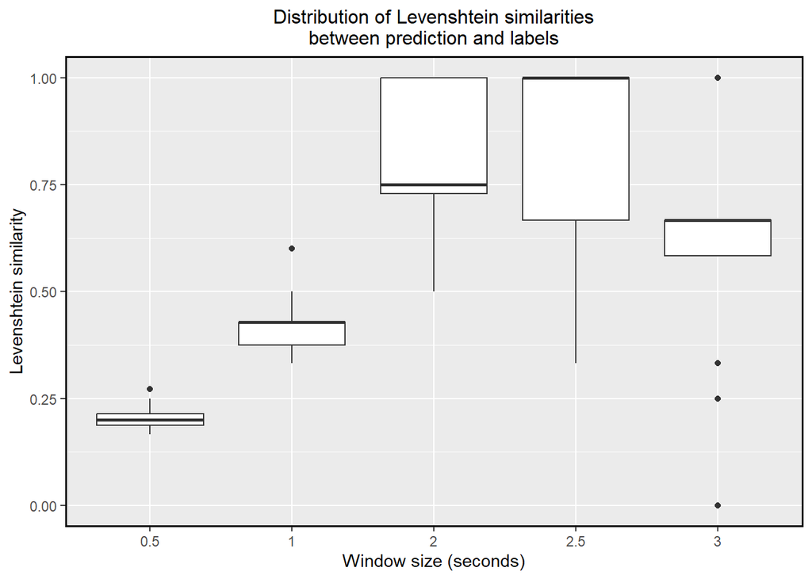

```r
# Initialising vectors to store results
short_results1 = short_results2 = short_results3 = short_results4 = short_results5 = numeric(length(wave_file_short))

# Calculating string similarities
for (i in 1:length(wave_file_short)) {
  label = wave_file_short[i] %>% names %>% gsub("\\_.*", "", .) # Remove last part of file name

  prediction1 = ts_features_classifier(wave_file_short[[i]], window_multiplier = 0.5)
  short_results1[i] = stringsim(label, prediction1, method = "lv")

  prediction2 = ts_features_classifier(wave_file_short[[i]], window_multiplier = 1)
  short_results2[i] = stringsim(label, prediction2, method = "lv")

  prediction3 = ts_features_classifier(wave_file_short[[i]], window_multiplier = 2)
  short_results3[i] = stringsim(label, prediction3, method = "lv")

  prediction4 = ts_features_classifier(wave_file_short[[i]], window_multiplier = 2.5)
  short_results4[i] = stringsim(label, prediction4, method = "lv")

  prediction5 = ts_features_classifier(wave_file_short[[i]], window_multiplier = 3)
  short_results5[i] = stringsim(label, prediction5, method = "lv")

}


# Storing results in a data frame
results_df = data.frame(lv_sim = c(short_results1,
                                   short_results2,
                                   short_results3,
                                   short_results4,
                                   short_results5),
                        group = rep(c("0.5", "1", "2", "2.5", "3"),
                                    each = length(wave_file_short)))



# Plotting the overall results
ggplot(data = results_df,
       mapping = aes(x = group, y = lv_sim)) +
  geom_boxplot() +
  labs(title = "Distribution of Levenshtein similarities\nbetween prediction and labels",
       x = "Window size (seconds)", y = "Levenshtein similarity") +
  theme(plot.title = element_text(hjust = 0.5, size = 12),
        panel.border = element_rect(colour = "black", fill = NA, size = 1))
```

```r
results_df %>% group_by(group) %>% summarise(mean(lv_sim))
```

```
## # A tibble: 5 × 2
##   group `mean(lv_sim)`
##   <chr>          <dbl>
## 1 0.5            0.207
## 2 1              0.426
## 3 2              0.819
## 4 2.5            0.785
## 5 3              0.580
```

- A window size of 2.5 seconds has the best median score.
- However a window size of 2 seconds has comparable results and less variability. Therefore we choose a window size of 2 seconds.

## Part (d)

Martin’s friend Alex thinks a zero-crossing classification rule will perform just as well to the Random Forest classifier.

Build a classification rule for detecting $\{L,R\}$ under a **streaming condition**, using the number of zero-crossings in a window to identify events (from Lab 3 Exercise 1.3), and using the min-max rule to classify events into “Left” or “Right” (Lab 3 Exercise 2.3). Use the optimal window size identified in part (c) as the window size.

Alex also thinks multiple thresholds must be evaluated to find the best zero-cross classification rule.

Compare the performance of the zero-cross classification rule using multiple thresholds. Which threshold gives the best performance? Justify your answer with appropriate visualisations.

#### Sample solution

We now use the basic skeleton code from part (b):

```r
zc_streaming_classifier = function(wave_file,
                                window_multiplier = 2,
                                thresholdEvents = 100) {

  window_size = wave_file@samp.rate*window_multiplier
  increment = window_size/3

  Y = wave_file@left
  xtime = seq_len(length(Y))/wave_file@samp.rate
  predicted_labels = c()
  window_lb = 1 # Lower bound of the window should start from index 1 (start of signal)
  max_time = length(Y)

  while(max_time > window_lb + window_size) {

    window_ub = window_lb + window_size
    window = Y[window_lb:window_ub]

    # Calculate number of zero crossings in the current window
    zero_crossings = sum(window[1:(length(window) - 1)] * window[2:(length(window))] <= 0)

    if (zero_crossings < thresholdEvents) {
      # Event detected, need to determine whether left or right
      predicted = LR_detection(window)
      predicted_labels = c(predicted_labels, predicted)
      window_lb = window_lb + window_size # Just found event; use larger increment
    } else {
      # No event detected; immediately move to next window
      window_lb = window_lb + increment # Still looking for event; use smaller increment
    }
  }
  return(paste(predicted_labels, collapse = "")) # Convert vector of predictions to string
}
```

`thresholdEvents` represent the (zero crossing) threshold under which a window will be recognised as an event.

As for the logic of the actual while loop, while the code should mostly be self-explanatory, a summary is given below:

- Until the window reaches the end of the file, continue the while loop. In particular, keep continuing until the lower bound of the window is within one window size away from the end of the file; if we try to start a new iteration in this case, then the end of the window will extend beyond the end of the file, which does not make sense.
- Calculate the number of zero crossings in the current window. If this number is below the threshold, then we say that there is an event. We call on `LR_detection` to classify this event as left or right, before storing the result in `predicted_labels` and moving the window forward. On the other hand, if this number is above the threshold, then we say that there is no event, and immediately move the window forward.
- If an event is detected, then the window is incremented forward by a larger amount (`window_size`) compared to the forward increment when an event is not detected. This is because we assume that after an event, there is not going to be another event for some time, and so moving forward the window a larger amount is more efficient. In addition, this approach helps us reduce multiple event detections for what is actually a single event in the data.

We apply our classifier, trying a range of thresholds.

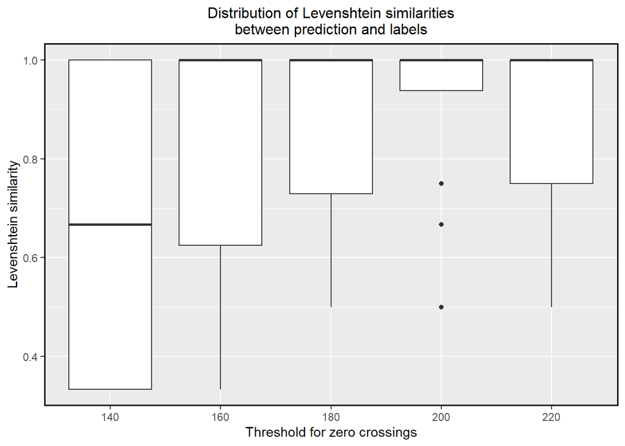

```r
# Initialising vectors to store results
short_results1 = short_results2 = short_results3 = short_results4 = short_results5 = numeric(length(wave_file_short))

# Calculating string similarities
for (i in 1:length(wave_file_short)) {
  label = wave_file_short[i] %>% names %>% gsub("\\_.*", "", .) # Remove last part of file name

  prediction1 = zc_streaming_classifier(wave_file_short[[i]], window_multiplier = 2, thresholdEvents = 140)
  short_results1[i] = stringsim(label, prediction1, method = "lv")

  prediction2 = zc_streaming_classifier(wave_file_short[[i]], window_multiplier = 2, thresholdEvents = 160)
  short_results2[i] = stringsim(label, prediction2, method = "lv")

  prediction3 = zc_streaming_classifier(wave_file_short[[i]], window_multiplier = 2, thresholdEvents = 180)
  short_results3[i] = stringsim(label, prediction3, method = "lv")

  prediction4 = zc_streaming_classifier(wave_file_short[[i]], window_multiplier = 2, thresholdEvents = 200)
  short_results4[i] = stringsim(label, prediction4, method = "lv")

  prediction5 = zc_streaming_classifier(wave_file_short[[i]], window_multiplier = 2, thresholdEvents = 220)
  short_results5[i] = stringsim(label, prediction5, method = "lv")

}


# Storing results in a data frame
results_df = data.frame(lv_sim = c(short_results1,
                                   short_results2,
                                   short_results3,
                                   short_results4,
                                   short_results5),
                        group = rep(c("140", "160", "180", "200", "220"),
                                    each = length(wave_file_short)))



# Plotting the overall results
ggplot(data = results_df,
       mapping = aes(x = group, y = lv_sim)) +
  geom_boxplot() +
  labs(title = "Distribution of Levenshtein similarities\nbetween prediction and labels",
       x = "Threshold for zero crossings", y = "Levenshtein similarity") +
  theme(plot.title = element_text(hjust = 0.5, size = 12),
        panel.border = element_rect(colour = "black", fill = NA, size = 1))
```

```r
results_df %>% group_by(group) %>% summarise(mean(lv_sim))
```

```
## # A tibble: 5 × 2
##   group `mean(lv_sim)`
##   <chr>          <dbl>
## 1 140            0.674
## 2 160            0.792
## 3 180            0.892
## 4 200            0.906
## 5 220            0.885
```

- We see that the best performing zero-crossing classifier is achieved with a threshold of 200 zero crossings (in a two second window); this classifier had the largest median Levenshtein similarity.
- A threshold of 200 is also the least variable out of all the thresholds.
- Statistical significance can be verified by using a t-test, for example.

## Part (e)

For both the best models that you found in part (c) and part (d), evaluate its performance on sequences of varying lengths. Does the length of the sequence have an impact on the classification accuracy? Which classifier performs the best on this data set, and why might you choose one over the other? Justify your answer with appropriate visualisations.

#### Sample solution

Here we read in all the short, medium, and long wave files, and apply both our classifiers to them. We plot our results on a boxplot.

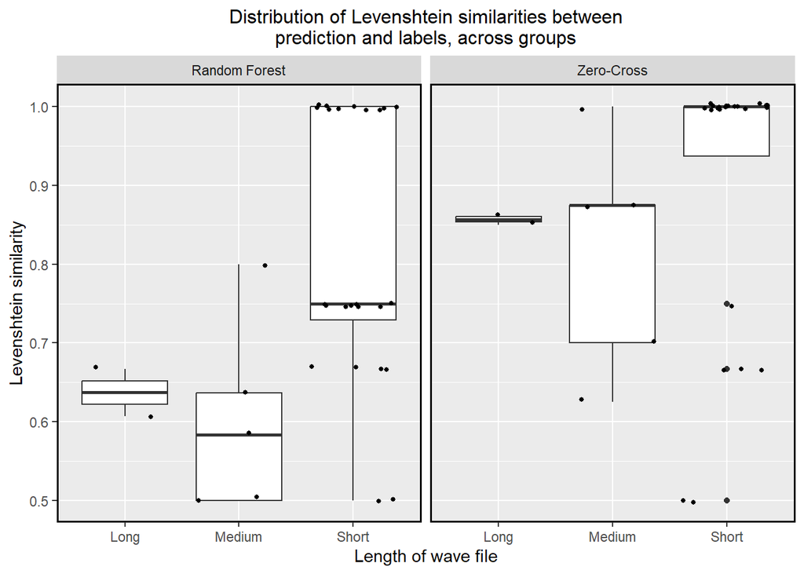

```r
# Setting optimal hyperparameters
window_multiplier = 2
thresholdEvents = 200


# Initialising vectors to store results
ts_short_results = zc_short_results = numeric(length(wave_file_short))
ts_medium_results = zc_medium_results = numeric(length(wave_file_medium))
ts_long_results = zc_long_results =  numeric(length(wave_file_long))


# Calculating string similarities for both classifiers
for (i in 1:length(wave_file_short)) {
  label = wave_file_short[i] %>% names %>% gsub("\\_.*", "", .) # Remove last part of file name

  ts_prediction = ts_features_classifier(wave_file_short[[i]], window_multiplier = window_multiplier)
  ts_short_results[i] = stringsim(label, ts_prediction, method = "lv")

  zc_prediction = zc_streaming_classifier(wave_file_short[[i]], window_multiplier = window_multiplier, thresholdEvents = thresholdEvents)
  zc_short_results[i] = stringsim(label, zc_prediction, method = "lv")
}

for (i in 1:length(wave_file_medium)) {
  label = wave_file_medium[i] %>% names %>% gsub("\\_.*", "", .) # Remove last part of file name

  ts_prediction = ts_features_classifier(wave_file_medium[[i]], window_multiplier = window_multiplier)
  ts_medium_results[i] = stringsim(label, ts_prediction, method = "lv")

  zc_prediction = zc_streaming_classifier(wave_file_medium[[i]], window_multiplier = window_multiplier, thresholdEvents = thresholdEvents)
  zc_medium_results[i] = stringsim(label, zc_prediction, method = "lv")
}

for (i in 1:length(wave_file_long)) {
  label = wave_file_long[i] %>% names %>% gsub("\\_.*", "", .) # Remove last part of file name

  ts_prediction = ts_features_classifier(wave_file_long[[i]], window_multiplier = window_multiplier)
  ts_long_results[i] = stringsim(label, ts_prediction, method = "lv")

  zc_prediction = zc_streaming_classifier(wave_file_long[[i]], window_multiplier = window_multiplier, thresholdEvents = thresholdEvents)
  zc_long_results[i] = stringsim(label, zc_prediction, method = "lv")

}



# Storing results in a data frame
ts_results_df = data.frame(
  lv_sim = c(ts_short_results,
             ts_medium_results,
             ts_long_results),
  group = rep(c("Short",
                "Medium",
                "Long"),
              c(
                length(wave_file_short),
                length(wave_file_medium),
                length(wave_file_long)
              )),
  classifier = "Random Forest"
)




zc_results_df = data.frame(
  lv_sim = c(zc_short_results,
             zc_medium_results,
             zc_long_results),
  group = rep(c("Short",
                "Medium",
                "Long"),
              c(
                length(wave_file_short),
                length(wave_file_medium),
                length(wave_file_long)
              )),
  classifier = "Zero-Cross"
)


combined_results = rbind(ts_results_df, zc_results_df)


# Plotting results
ggplot(data = combined_results,
       mapping = aes(x = group, y = lv_sim)) +
  geom_boxplot() +
  geom_jitter(size = 1) +
  facet_wrap(~classifier) +
  labs(title = paste("Distribution of Levenshtein similarities between",
                     "\nprediction and labels, across groups", sep = ""),
       x = "Length of wave file", y = "Levenshtein similarity") +
  theme(plot.title = element_text(hjust = 0.5, size = 12),
        panel.border = element_rect(colour = "black", fill = NA, size = 1))
```